# Lecture5. Схема аналізу

October 5, 2019

## Exploratory Data Analysis

Візьмемо дані з марафону ВізЕйр 2018 року.

```r
library(readr)
maraphon <- read_delim("maraphon.csv",
                       delim=";",
                       col_names = c("Name","gender","id","year",
                                     "age_group","club","city","country",
                                     "place", "net_time", "gross_time"))
```

## Основні інструменти. Описова статистика

- Mean - arithmetic average
- Median - middle value
- Mode - most frequent value
- Standard Deviation - variation around the mean
- Interquartile Range - range encompasses 50% of the values
- Kurtosis - peakedness of the data distribution
- Skewness - symmetry of the data distribution

## Основні інструменти. Графічні методи

- Histogram - a bar plot where each bar represents the frequency of observations for a given range of values
- Density estimation - an estimation of the frequency distribution based on the sample data
- Quantile-quantile plot - a plot of the actual data values against a normal distribution
- Box plots - a visual representation of median, quartiles, symmetry, skewness, and outliers
- Scatter plots - a graphical display of one variable plotted on the x axis and another on the y axis
- Radial plots - plots formatted for the representation of circular data

## 1. Етап. Вивчення даних

```r
#Install if the package doesn't exist
#install.packages('DataExplorer')
library(DataExplorer)
```

## Характеристики датасету

```r
str(maraphon)
```

```
## Classes 'tbl_df', 'tbl' and 'data.frame':    400 obs. of  11 variables:
##  $ Name      : chr  "Сергій Марчук " "Юлия Тарасевич" "Івах Віталій" "Вікторія Чайка" ...
##  $ gender    : chr  "Ч" "Ж" "Ч" "Ж" ...
##  $ id        : int  4998 3416 2973 2278 4967 4908 2095 2241 2052 4398 ...
##  $ year      : int  1986 1996 1996 1996 1982 1991 1996 1969 1986 1977 ...
##  $ age_group : chr  "30 - 39" "23 - 29" "23 - 29" "23 - 29" ...
##  $ club      : chr  NA "Регион/Виктория" "Sumy Running Club" NA ...
##  $ city      : chr  "Ковель" "Molodechno" "Суми" "Kyiv" ...
##  $ country   : chr  "Ukraine" "Belarus" "Ukraine" "Ukraine" ...
##  $ place     : int  NA NA NA NA NA NA NA NA NA NA ...
##  $ net_time  : chr  "1:11:29,0" "1:25:37,4" "1:12:26,2" "1:27:56,5" ...
##  $ gross_time: chr  "1:11:32,0" "1:25:44,6" "1:12:29,0" "1:28:00,5" ...
##  - attr(*, "spec")=List of 2
##   ..$ cols   :List of 11
##   .. ..$ Name      : list()
##   .. .. ..- attr(*, "class")= chr  "collector_character" "collector"
##   .. ..$ gender    : list()
##   .. .. ..- attr(*, "class")= chr  "collector_character" "collector"
##   .. ..$ id        : list()
##   .. .. ..- attr(*, "class")= chr  "collector_integer" "collector"
##   .. ..$ year      : list()
##   .. .. ..- attr(*, "class")= chr  "collector_integer" "collector"
##   .. ..$ age_group : list()
##   .. .. ..- attr(*, "class")= chr  "collector_character" "collector"
##   .. ..$ club      : list()
##   .. .. ..- attr(*, "class")= chr  "collector_character" "collector"
##   .. ..$ city      : list()
##   .. .. ..- attr(*, "class")= chr  "collector_character" "collector"
##   .. ..$ country   : list()
##   .. .. ..- attr(*, "class")= chr  "collector_character" "collector"
##   .. ..$ place     : list()
##   .. .. ..- attr(*, "class")= chr  "collector_integer" "collector"
##   .. ..$ net_time  : list()
##   .. .. ..- attr(*, "class")= chr  "collector_character" "collector"
##   .. ..$ gross_time: list()
##   .. .. ..- attr(*, "class")= chr  "collector_character" "collector"
##   ..$ default: list()
##   .. ..- attr(*, "class")= chr  "collector_guess" "collector"
##   ..- attr(*, "class")= chr "col_spec"
```

## Характеристики змінних. Стать

```r
maraphon$gender <- factor(maraphon$gender)
summary(maraphon$gender)
```

```
##   Ж   Ч
## 200 200
```

## Характеристики змінних. Рік народження.

```r
library(lubridate)
maraphon$year <- year(parse_date_time(maraphon$year,orders = "y"))
maraphon$age_group <- factor(maraphon$age_group)
```

## Характеристики змінних. Час - треба повозитись

```r
options(digits.secs=3)
maraphon$net_time <- gsub(",",".",maraphon$net_time)
maraphon$net_time <- strptime(maraphon$net_time, "%H:%M:%OS")
maraphon$gross_time <- gsub(",",".",maraphon$gross_time)
maraphon$gross_time <- strptime(maraphon$gross_time, "%H:%M:%OS")
```

```r
str(maraphon)
```

```
## Classes 'tbl_df', 'tbl' and 'data.frame':    400 obs. of  11 variables:
##  $ Name      : chr  "Сергій Марчук " "Юлия Тарасевич" "Івах Віталій" "Вікторія Чайка" ...
##  $ gender    : Factor w/ 2 levels "Ж","Ч": 2 1 2 1 2 1 2 1 2 1 ...
##  $ id        : int  4998 3416 2973 2278 4967 4908 2095 2241 2052 4398 ...
##  $ year      : num  1986 1996 1996 1996 1982 ...
##  $ age_group : Factor w/ 5 levels "18 - 22","23 - 29",..: 3 2 2 2 3 2 2 5 3 4 ...
##  $ club      : chr  NA "Регион/Виктория" "Sumy Running Club" NA ...
##  $ city      : chr  "Ковель" "Molodechno" "Суми" "Kyiv" ...
##  $ country   : chr  "Ukraine" "Belarus" "Ukraine" "Ukraine" ...
##  $ place     : int  NA NA NA NA NA NA NA NA NA NA ...
##  $ net_time  : POSIXlt, format: "2019-10-07 01:11:29.0" "2019-10-07 01:25:37.4" ...
##  $ gross_time: POSIXlt, format: "2019-10-07 01:11:32.0" "2019-10-07 01:25:44.6" ...
##  - attr(*, "spec")=List of 2
##   ..$ cols   :List of 11
##   .. ..$ Name      : list()
##   .. .. ..- attr(*, "class")= chr  "collector_character" "collector"
##   .. ..$ gender    : list()
##   .. .. ..- attr(*, "class")= chr  "collector_character" "collector"
##   .. ..$ id        : list()
##   .. .. ..- attr(*, "class")= chr  "collector_integer" "collector"
##   .. ..$ year      : list()
##   .. .. ..- attr(*, "class")= chr  "collector_integer" "collector"
##   .. ..$ age_group : list()
##   .. .. ..- attr(*, "class")= chr  "collector_character" "collector"
##   .. ..$ club      : list()
##   .. .. ..- attr(*, "class")= chr  "collector_character" "collector"
##   .. ..$ city      : list()
##   .. .. ..- attr(*, "class")= chr  "collector_character" "collector"
##   .. ..$ country   : list()
##   .. .. ..- attr(*, "class")= chr  "collector_character" "collector"
##   .. ..$ place     : list()
##   .. .. ..- attr(*, "class")= chr  "collector_integer" "collector"
##   .. ..$ net_time  : list()
##   .. .. ..- attr(*, "class")= chr  "collector_character" "collector"
##   .. ..$ gross_time: list()
##   .. .. ..- attr(*, "class")= chr  "collector_character" "collector"
##   ..$ default: list()
##   .. ..- attr(*, "class")= chr  "collector_guess" "collector"
##   ..- attr(*, "class")= chr "col_spec"
```

## Характеристика кожної змінної. Стать

```r
table(maraphon$gender)
```

```
##
##   Ж   Ч
## 200 200
```

## Характеристика кожної змінної. Рік народження

```r
table(maraphon$year)
hist(maraphon$year)
```

[output not shown]

## Характеристика кожної змінної. Рік народження

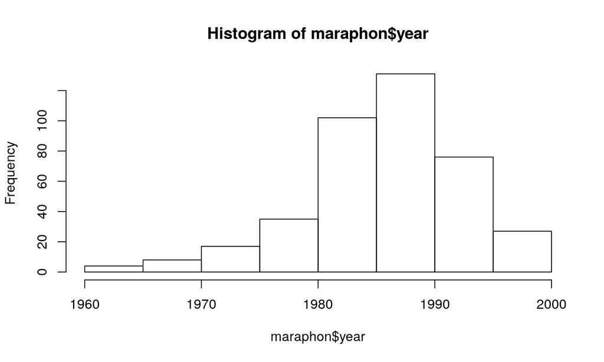

## Характеристика кожної змінної. Вікова група

```r
table(maraphon$age_group)
```

```
##
## 18 - 22 23 - 29 30 - 39 40 - 49 50 - 59
##      14     116     210      50      10
```

## Характеристика кожної змінної. Країна

```r
table(maraphon$country)
```

```
##
##      Australia        Belarus          China         France        Germany
##              1             12              1              3              5
##         Israel          Italy      Lithuania         Norway         Poland
##              2              2              1              2              3
##          Spain         Sweden        Ukraine United Kingdom  United States
##              1              2            361              1              3
```

## Завдання. Використати Dplyr

1. Створити новий датафрейм в який вибрати id, age_group, gender, country, net_time
2. Виборати лише спортсменів з України і видалити колонку country.
3. Відсортувати всі рядки за часом забігу і додати колонку "загальне місце".
4. Вибрати першу десятку окремо по кожній віковій групі.

## Описова статистика часу забігу.

1. Потрібно перевести час у число (так зручніше). Найкраще перевести у секунди.
2. Додати колонку вік Як це зробити? (5 хв)

## Описова статистика часу забігу.

```r
library(lubridate)
t.lub <- ymd_hms(maraphon$net_time)
hour(t.lub[2])
```

```
## [1] 1
```

```r
minute(t.lub[2])
```

```
## [1] 25
```

```r
second(t.lub[2])
```

```
## [1] 37.4
```

```r
to_seconds <- function(t) {
  return(hour(t)*3600 + minute(t)*60 + second(t))
}
maraphon$seconds <- to_seconds(maraphon$net_time)
maraphon$gross_seconds <- to_seconds(maraphon$gross_time)
maraphon$net_time <- NULL
maraphon$gross_time <- NULL
```

## Виберем всі перші місця

```r
library(dplyr)
maraphon %>%
  filter(place == 1) %>%
  select(Name,gender,age_group, seconds) %>%
  arrange(age_group,gender)
```

[output not shown]

## Описова статистика

```r
mean(maraphon$seconds)
```

```
## [1] 6094.199
```

```r
median(maraphon$seconds)
```

```
## [1] 5965.75
```

## Мода - найчастіше значення

```r
sort(table(round(maraphon$year)), decreasing = TRUE)[1]
```

```
## 1989
##   36
```

## Таблиця частот

```r
table(maraphon$gender,maraphon$year)
```

```
##
##     1961 1963 1965 1966 1967 1968 1969 1970 1971 1972 1973 1974 1975 1976
##   Ж    0    1    1    0    0    1    2    0    0    2    1    3    2    0
##   Ч    1    1    0    1    1    1    0    2    3    2    4    0    0    4
##
##     1977 1978 1979 1980 1981 1982 1983 1984 1985 1986 1987 1988 1989 1990
##   Ж    4    6    6    3    3    7   10   13    7   10   15   18   17   13
##   Ч    4    4    3    1    4    9   14   18   17   14   10    1   19   14
##
##     1991 1992 1993 1994 1995 1996 1997 1998 1999
##   Ж   13   11    6    8    3    7    3    3    1
##   Ч    9   14    3    5    4    6    4    3    0
```

## Завдання.

Вивести всі роки, де жінок більше ніж чоловіків.

## Додати суми до таблиці

```r
addmargins(table(maraphon$gender,maraphon$year))
```

```
##
##       1961 1963 1965 1966 1967 1968 1969 1970 1971 1972 1973 1974 1975
##   Ж      0    1    1    0    0    1    2    0    0    2    1    3    2
##   Ч      1    1    0    1    1    1    0    2    3    2    4    0    0
##   Sum    1    2    1    1    1    2    2    2    3    4    5    3    2
##
##       1976 1977 1978 1979 1980 1981 1982 1983 1984 1985 1986 1987 1988
##   Ж      0    4    6    6    3    3    7   10   13    7   10   15   18
##   Ч      4    4    4    3    1    4    9   14   18   17   14   10    1
##   Sum    4    8   10    9    4    7   16   24   31   24   24   25   19
##
##       1989 1990 1991 1992 1993 1994 1995 1996 1997 1998 1999 Sum
##   Ж     17   13   13   11    6    8    3    7    3    3    1 200
##   Ч     19   14    9   14    3    5    4    6    4    3    0 200
##   Sum   36   27   22   25    9   13    7   13    7    6    1 400
```

## Таблиця з відсотками

```r
round(prop.table(table(maraphon$gender,maraphon$year), margin = 2) * 100)
```

```
##
##     1961 1963 1965 1966 1967 1968 1969 1970 1971 1972 1973 1974 1975 1976
##   Ж    0   50  100    0    0   50  100    0    0   50   20  100  100    0
##   Ч  100   50    0  100  100   50    0  100  100   50   80    0    0  100
##
##     1977 1978 1979 1980 1981 1982 1983 1984 1985 1986 1987 1988 1989 1990
##   Ж   50   60   67   75   43   44   42   42   29   42   60   95   47   48
##   Ч   50   40   33   25   57   56   58   58   71   58   40    5   53   52
##
##     1991 1992 1993 1994 1995 1996 1997 1998 1999
##   Ж   59   44   67   62   43   54   43   50  100
##   Ч   41   56   33   38   57   46   57   50    0
```

## Агрегування 1. Час пробігу - стать

```r
library(dplyr)
maraphon %>%
  group_by(age_group, gender) %>%
  summarise(mean_seconds = mean(seconds))
```

```
## # A tibble: 10 x 3
## # Groups:   age_group [5]
##    age_group gender mean_seconds
##    <fct>     <fct>         <dbl>
##  1 18 - 22   Ж             6244.
##  2 18 - 22   Ч             5601.
##  3 23 - 29   Ж             6581.
##  4 23 - 29   Ч             5593.
##  5 30 - 39   Ж             6644.
##  6 30 - 39   Ч             5588.
##  7 40 - 49   Ж             6469.
##  8 40 - 49   Ч             5687.
##  9 50 - 59   Ж             6561.
## 10 50 - 59   Ч             5503.
```

## Квантілі і інші функції

```r
library(dplyr)
maraphon <- maraphon %>%
  mutate(age = 2019 - year)

summary(maraphon$age)
```

```
##    Min. 1st Qu.  Median    Mean 3rd Qu.    Max.
##   20.00   28.00   32.00   32.83   36.00   58.00
```

```r
quantile(maraphon$age)
```

```
##   0%  25%  50%  75% 100%
##   20   28   32   36   58
```

```r
range(maraphon$age)
```

```
## [1] 20 58
```

## Графічні методи

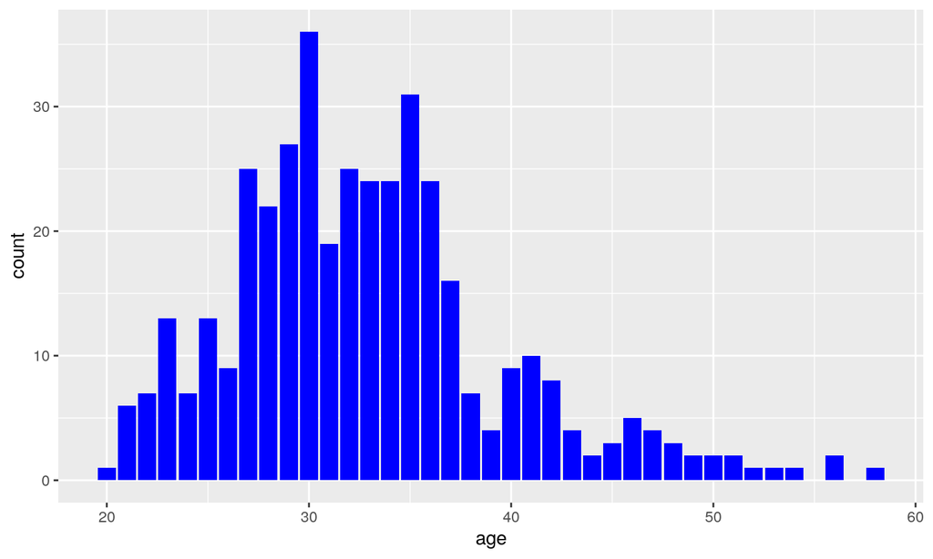

```r
ggplot(maraphon, aes(age)) +
  geom_bar(fill = 'blue')
```

## Гістограма

Питання - як рознести на два графіка або прибрати накладення?

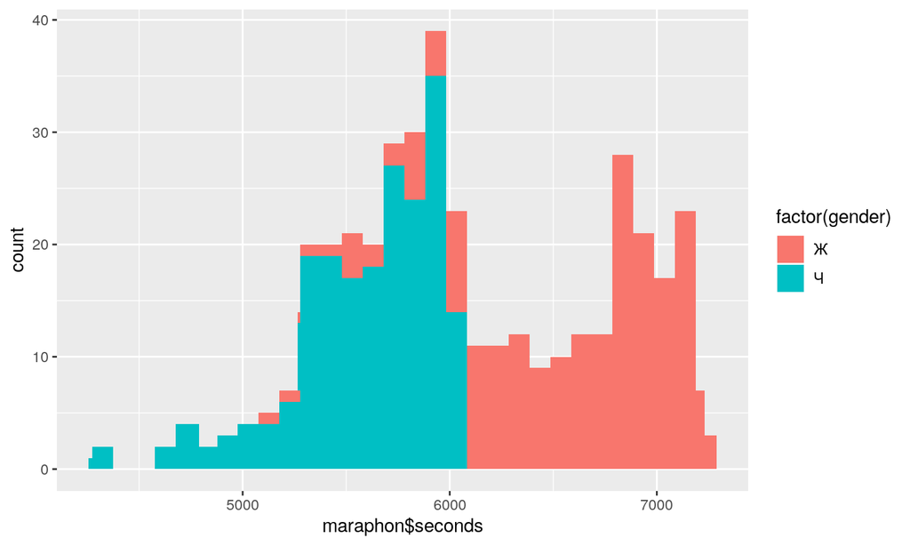

```r
ggplot(maraphon, aes(x = maraphon$seconds, fill = factor(gender))) +
  geom_histogram(bins = 50) +
  stat_bin()
```

## Гістограма

Питання - як рознести на два графіка або прибрати накладення?

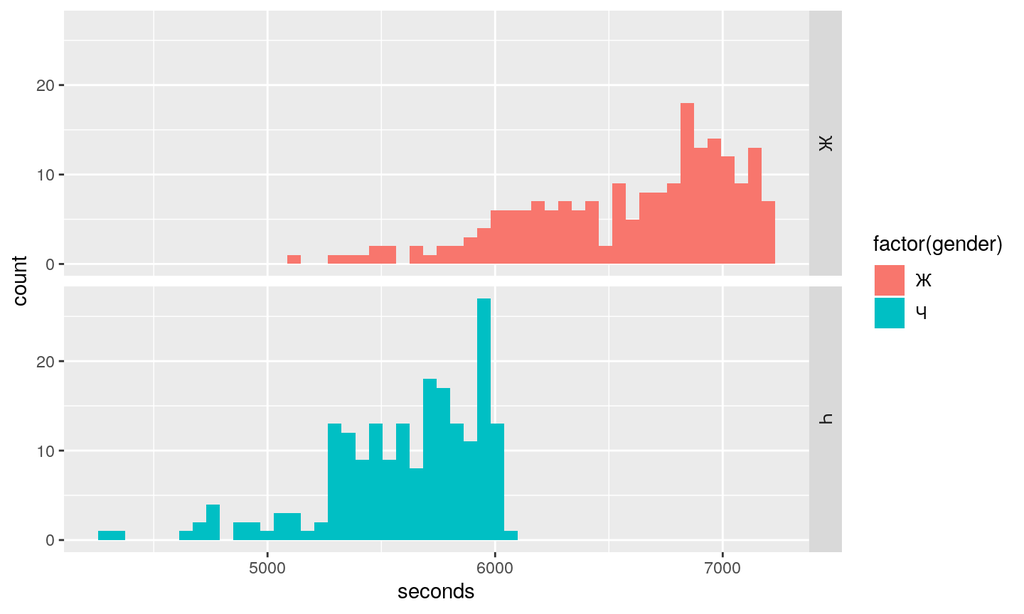

```r
ggplot(maraphon, aes(seconds, fill = factor(gender))) +
  geom_histogram(bins = 50) +
  facet_grid(maraphon$gender)
```

## Щільність розподілу

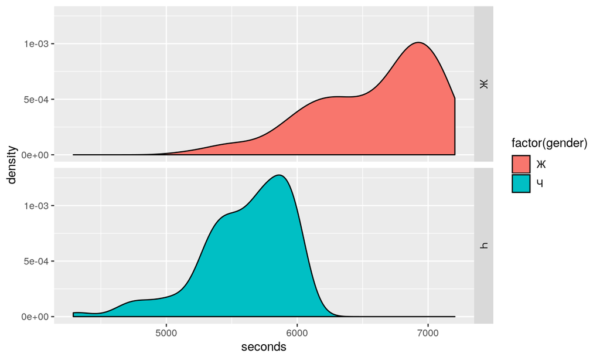

```r
ggplot(maraphon, aes(seconds, fill = factor(gender))) +
  geom_density(bins = 50) +
  facet_grid(maraphon$gender)
```

## Boxplot

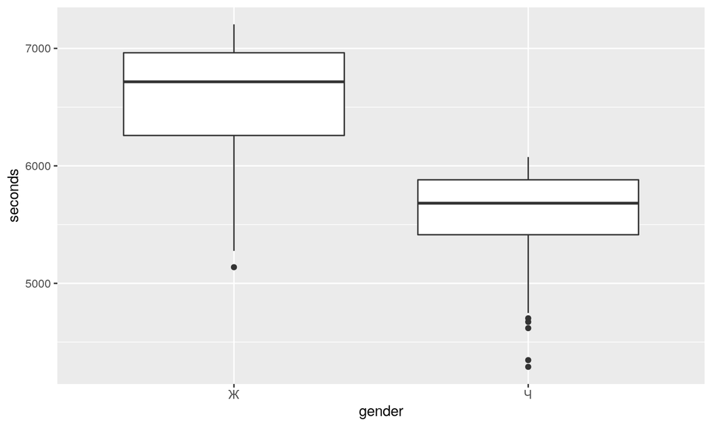

```r
ggplot(maraphon, aes(gender,seconds)) +
  geom_boxplot()
```

## QQ-plot

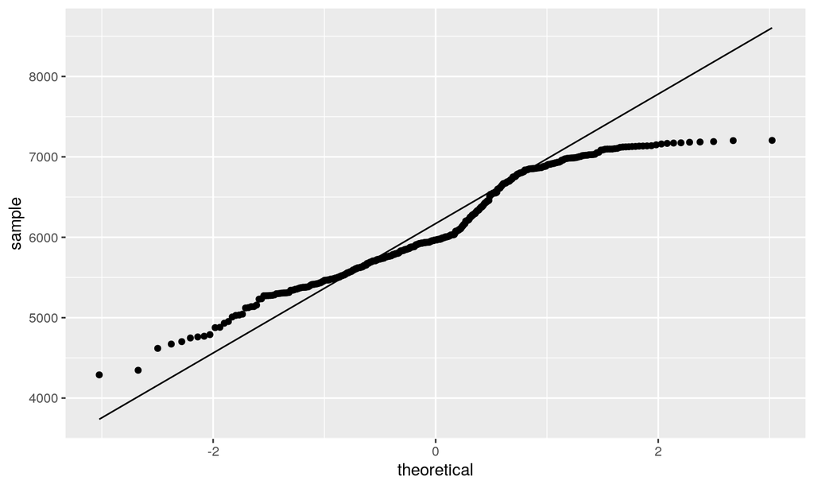

```r
ggplot(maraphon, aes(sample= seconds)) +
  geom_qq() +
  geom_qq_line()
```

## QQ-plot

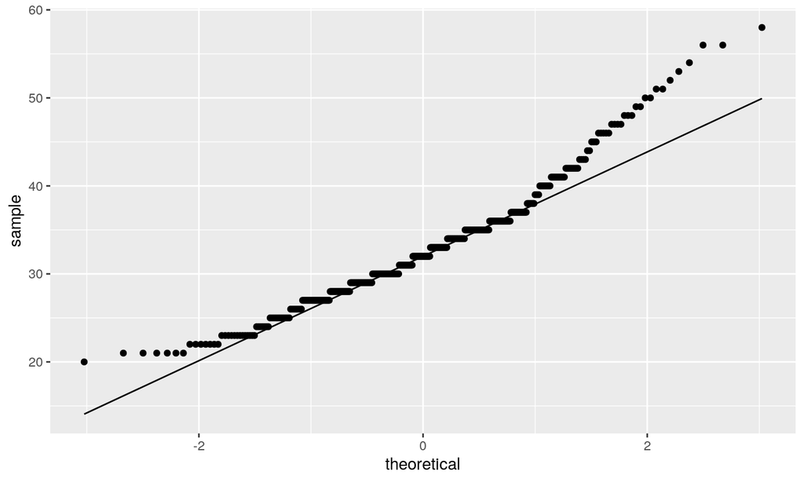

```r
ggplot(maraphon, aes(sample = age)) +
  geom_qq() +
  geom_qq_line()
```

## Точкові графіки

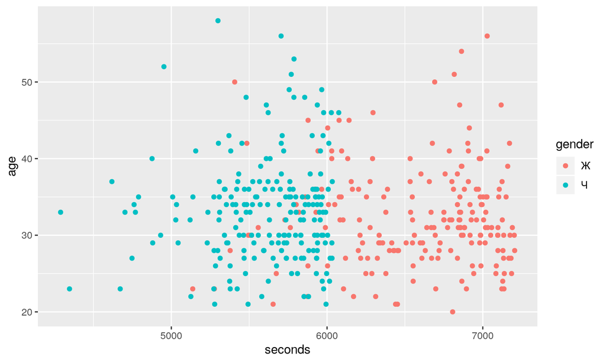

```r
ggplot(maraphon, aes(seconds, age)) +
  geom_point(aes(color = gender))
```

## За групами і статтю

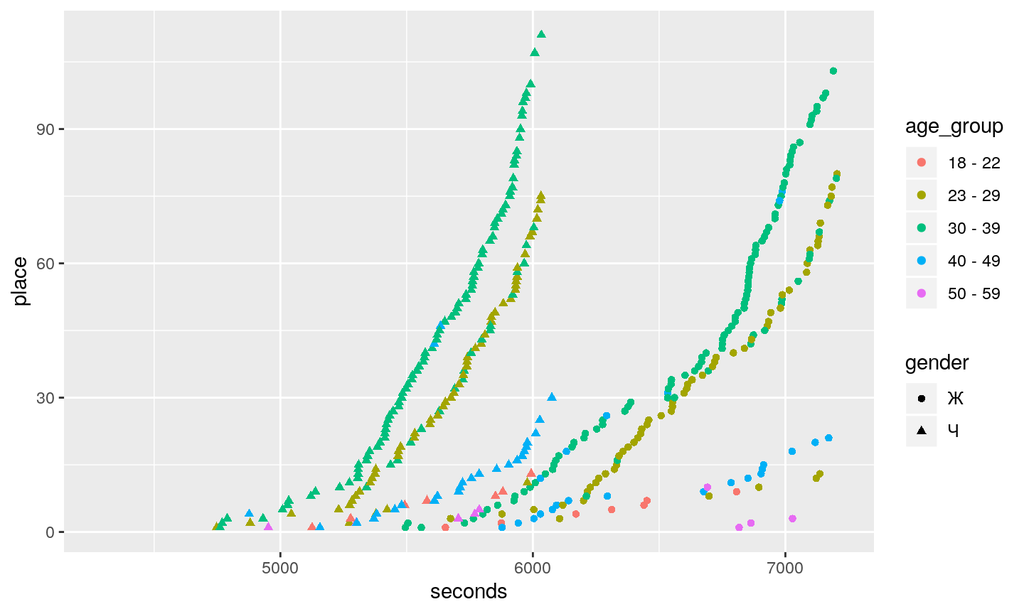

```r
ggplot(maraphon, aes(seconds, place)) +
  geom_point(aes(color = age_group, shape = gender),na.rm = TRUE)
```

## пакет DataExplore

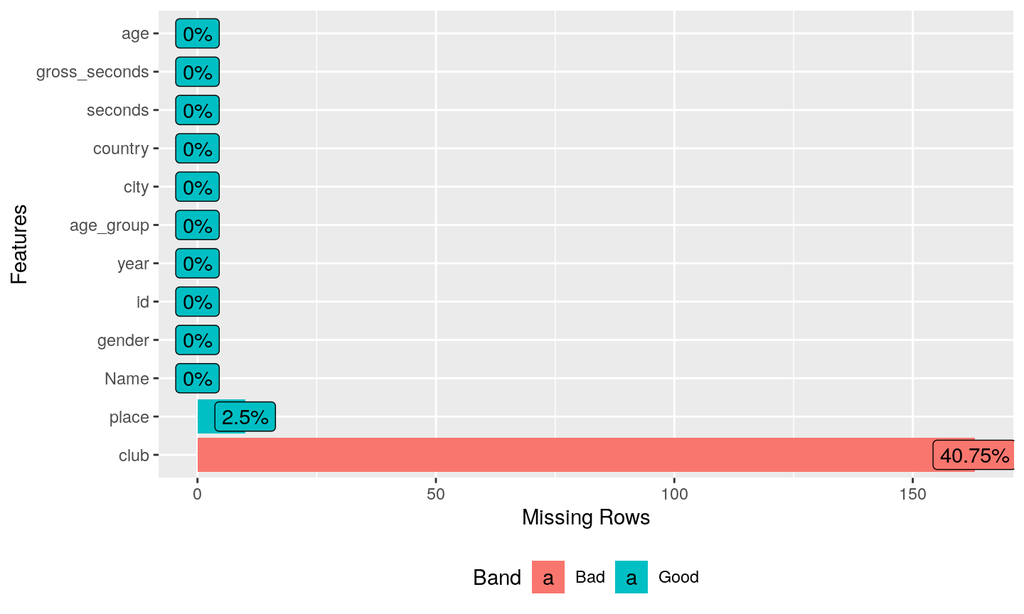

```r
plot_missing(maraphon)
```

## Гістограми

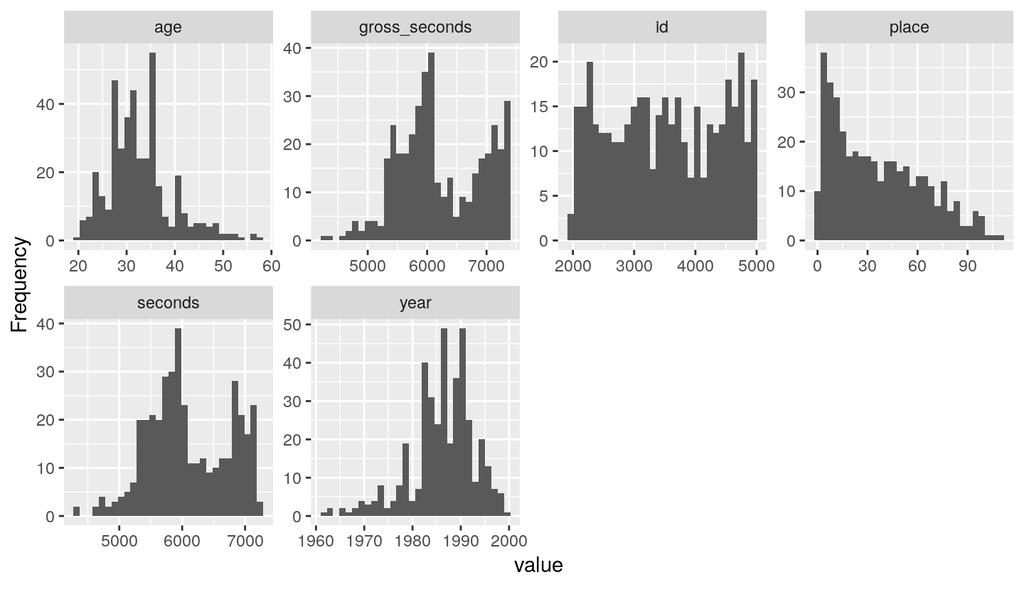

```r
plot_histogram(maraphon)
```

## Кореляції

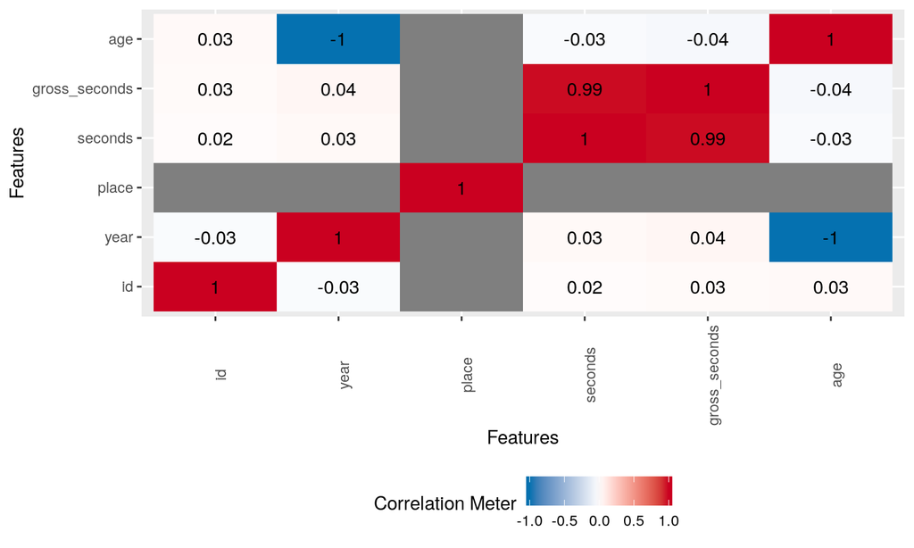

```r
plot_correlation(maraphon, type = 'continuous','Review.Date')
```

## Категоріальні змінні

```
## 3 columns ignored with more than 50 categories.
## Name: 400 categories
## club: 144 categories
## city: 73 categories
```

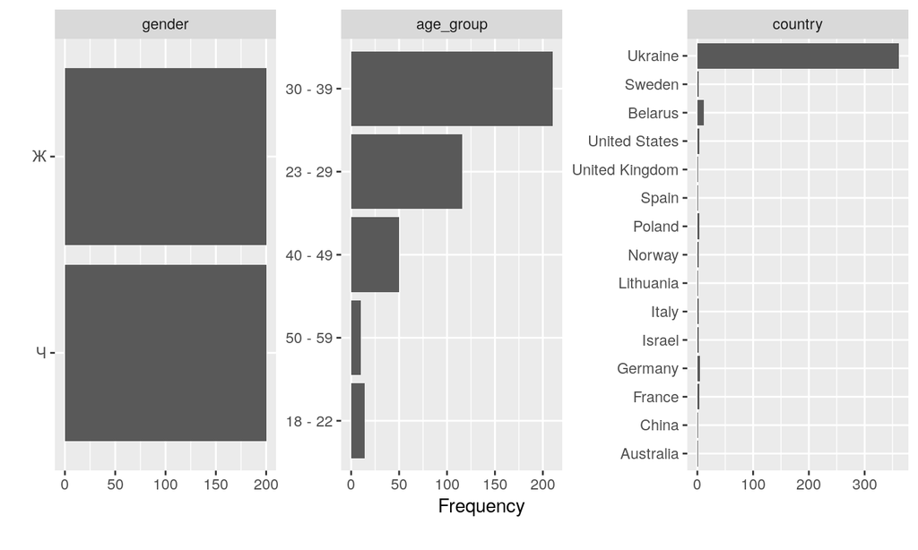

```r
plot_bar(maraphon)
```

## Boxplot

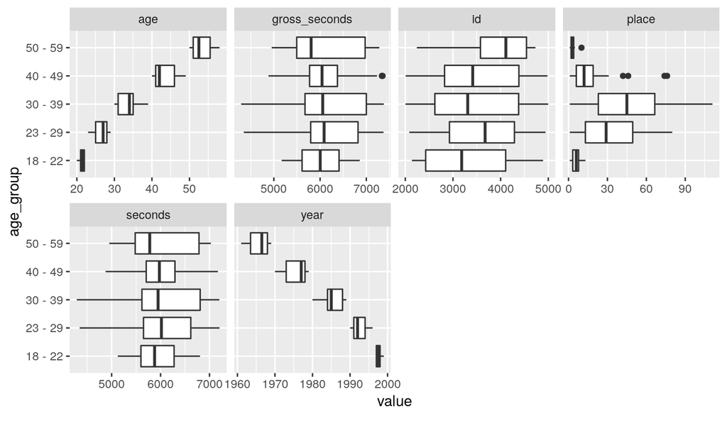

```r
plot_boxplot(maraphon, by = "age_group")
```

## Точковий графік

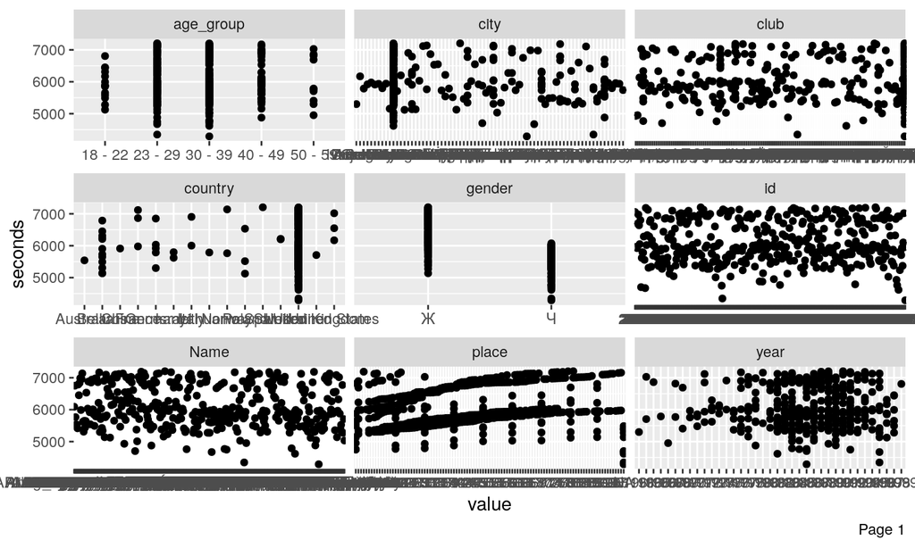

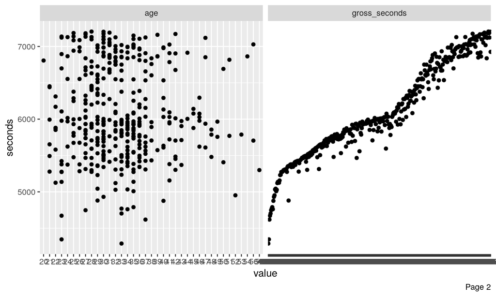

```r
plot_scatterplot(maraphon, by = "seconds")
```

## Кластерізація

```r
kmeansObj <- kmeans(maraphon[c("seconds","age")], centers = 2)
names(kmeansObj)
```

```
## [1] "cluster"      "centers"      "totss"        "withinss"
## [5] "tot.withinss" "betweenss"    "size"         "iter"
## [9] "ifault"
```

```r
kmeansObj
```

```
## K-means clustering with 2 clusters of sizes 152, 248
##
## Cluster means:
##    seconds      age
## 1 6800.674 32.14474
## 2 5661.199 33.25000
##
## Clustering vector:
##   [1] 2 2 2 2 2 2 2 2 2 2 2 2 2 2 2 2 2 2 2 2 2 2 2 2 2 2 2 2 2 2 2 2 2 2 2
##  [36] 2 2 2 2 2 2 2 2 2 2 2 2 2 2 2 2 2 2 2 2 2 2 2 2 2 2 2 2 2 2 2 2 2 2 2
##  [71] 2 2 2 2 2 2 2 2 2 2 2 2 2 1 2 2 2 1 2 2 1 2 2 2 1 2 2 1 2 2 2 2 1 2 2
## [106] 1 1 2 1 2 2 1 1 2 2 2 2 1 1 2 2 1 2 2 2 1 2 1 1 2 1 2 1 2 2 1 1 2 1 2
## [141] 1 2 1 2 1 2 1 2 1 2 2 1 1 2 1 2 1 2 2 1 2 1 2 1 2 1 2 1 2 1 2 1 1 2 1
## [176] 2 1 2 1 2 1 2 1 2 1 2 2 1 2 1 2 1 1 2 2 1 1 2 2 1 1 2 2 1 1 2 1 2 2 1
## [211] 2 1 1 2 2 1 1 2 1 2 2 1 1 2 2 1 1 2 2 1 2 1 1 2 2 1 2 1 1 2 1 2 1 2 1
## [246] 2 2 1 2 1 2 1 2 1 1 2 2 1 2 1 1 2 1 2 1 2 1 2 2 1 1 2 2 1 1 2 2 1 2 1
## [281] 1 2 2 1 1 2 1 2 2 1 1 2 2 1 1 2 2 1 2 1 1 2 2 1 1 2 2 1 2 1 2 1 1 2 1
## [316] 2 1 2 1 2 2 1 1 2 1 2 2 1 2 1 2 1 2 1 2 1 2 1 1 2 2 1 2 1 1 2 1 2 2 1
## [351] 1 2 1 2 2 1 2 1 2 1 1 2 1 2 1 2 2 1 2 1 1 2 1 2 2 1 2 1 2 1 2 1 1 2 1
## [386] 2 1 2 1 2 2 1 2 1 1 2 2 1 1 2
##
## Within cluster sum of squares by cluster:
## [1] 10821434 31171477
##  (between_SS / total_SS =  74.4 %)
##
## Available components:
##
## [1] "cluster"      "centers"      "totss"        "withinss"
## [5] "tot.withinss" "betweenss"    "size"         "iter"
## [9] "ifault"
```

## Кластери

```r
head(table(maraphon$Name, kmeansObj$cluster),20)
```

```
##
##                         1 2
##   Aleksey Ivanov        0 1
##   Alena Shvayka         1 0
##   Alexander Ginda       0 1
##   Alexander Sotishvili  0 1
##   Alexandr Groza        0 1
##   Alexey Koval          0 1
##   Aliaksandra Tapunova  1 0
##   Alina Gromova         1 0
##   Alina Syzon           1 0
##   Alisa Korn            1 0
##   Alla Vorobyova        0 1
##   Anastasiia Kolyvushko 1 0
##   Anastasiya Petruk     1 0
##   Anatoly Goldstein     0 1
##   Andrii Khvedchuk      0 1
##   Andrii Mazhara        0 1
##   Andriienko Andrii     0 1
##   Andriy Shcherbyna     0 1
##   Anna Vinitskaja       1 0
##   Anna Volkova          0 1
```

## Візуалізація кластерів

```r
maraphon$cluster=factor(kmeansObj$cluster)
centers=as.data.frame(kmeansObj$centers)
```

## Нарешті

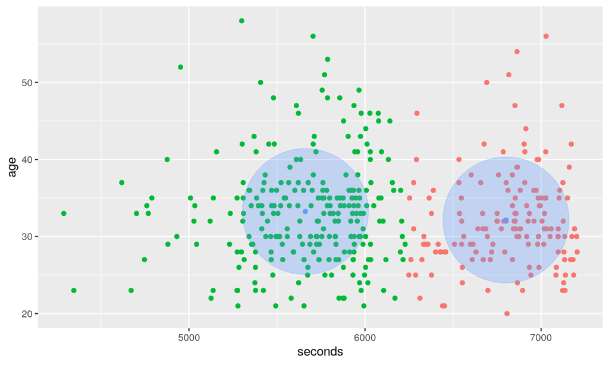

```r
ggplot(data=maraphon, aes(x=seconds, y=age, color=cluster)) +
 geom_point() +
 geom_point(data=centers, aes(x=seconds,y=age,color='Center')) +
 geom_point(data=centers, aes(x=seconds,y=age, color='Center'), size=52, alpha=.3) +
  theme(legend.position = "none")
```